# Binary and multinomial logistic regression analysis

*This document covers all the functions that Bill mentions in the lecture or used in his script about binary and multinomial logistic regression. The order of functions is as you would use them to perform logistic regression. How to use this file for the exam: Scroll through this file and look at the table of content on the left side. For each subchapter, functions that Bill used will appear. Whenever you see a function you don’t know, check it out. For each function, the package to which it belongs is mentioned in parenthesis. If no package is mentioned, the function belongs to the basic R environment. Also, for each function a short description is given and the arguments that Bill presented are mentioned (not all possible arguments are listed and in very obvious cases I don’t mention the arguments or only mention them in the short written description). The assumptions, including the functions needed to test them, are listed but the concepts behind logistic regression and the assumptions are only covered very superficially like in the lecture since we already did that in the first course. I think if you cover and understand this document you will be able to answer all exam questions about logistic regression and multinomial regression. However, I want to note that I would not perform this type of analysis in the way it is presented here and I also would not present assumption testing in the way it was shown to us. The focus here is merely to prepare for the exam*

# Binary logistic regression

## Import data

### read.spss (foreign)

Used to import data from the *.SAV* fileformat that is used by SPSS.

###### to.data.frame

Logical: Store as dataframe (it would otherwise we stored in a list format in the below example)

###### use.value.labels

Logical: Lets R convert variables with value labels into R factors. Alternatively, you could leave it out and specify factors manually by using `factor(variable_name)`

```r
library(foreign)
#optional: specify filename beforehand
filename <- 'https://github.com/HenrikEckermann/website/raw/master/mysite/main/templates/stats/logistic_regression/collaboration_for_exam/logreg.sav'
#the filename can be any direct link to the file. So, a filepath to a directory or a link like the one that I stored in the variable 'filename'
df <- read.spss(filename, to.data.frame=TRUE, use.value.labels=TRUE)
#The result is a dataframe:
head(df)
```

|  | id | age | sex | satjob | educ | hours | life | income |
| --- | --- | --- | --- | --- | --- | --- | --- | --- |
| 1 | 1 | 43 | Male | Not very satisfied | 11 | 35 | Routine | $35000-39999 |
| 2 | 2 | 44 | Male | Not very satisfied | 16 | 21 | Exciting | $40000-49999 |
| 3 | 3 | 43 | Female | Very satisfied | 16 | 45 | Exciting | $40000-49999 |
| 4 | 4 | 45 | Female | Not very satisfied | 15 | 20 | NA | NA |
| 5 | 5 | 78 | Female | NA | 17 | NA | Exciting | NA |
| 6 | 6 | 83 | Male | NA | 11 | NA | Routine | NA |

## Missing value analysis

### aggr (VIM)

Use this function to analyze patterns of missingness:

###### numbers

Logical: Indicates whether the proportion or frequencies of the different combinations should be represented by numbers in the output.

###### prop

Logical: Indicates whether the proportion of missing/imputed values and combinations should be used rather than the total amount.

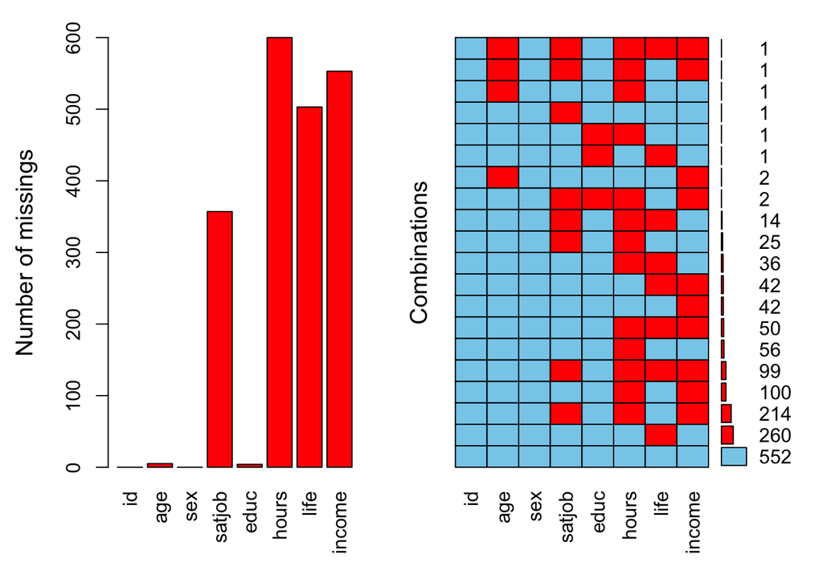

```r
library(VIM)
aggr(df, numbers=TRUE, prop=F)
```

### histMiss (VIM)

To check for patterns of missingness between two variables. Here age and satjob are compared. We see that with increasing age there is more missingness occuring for the variable *satjob*.

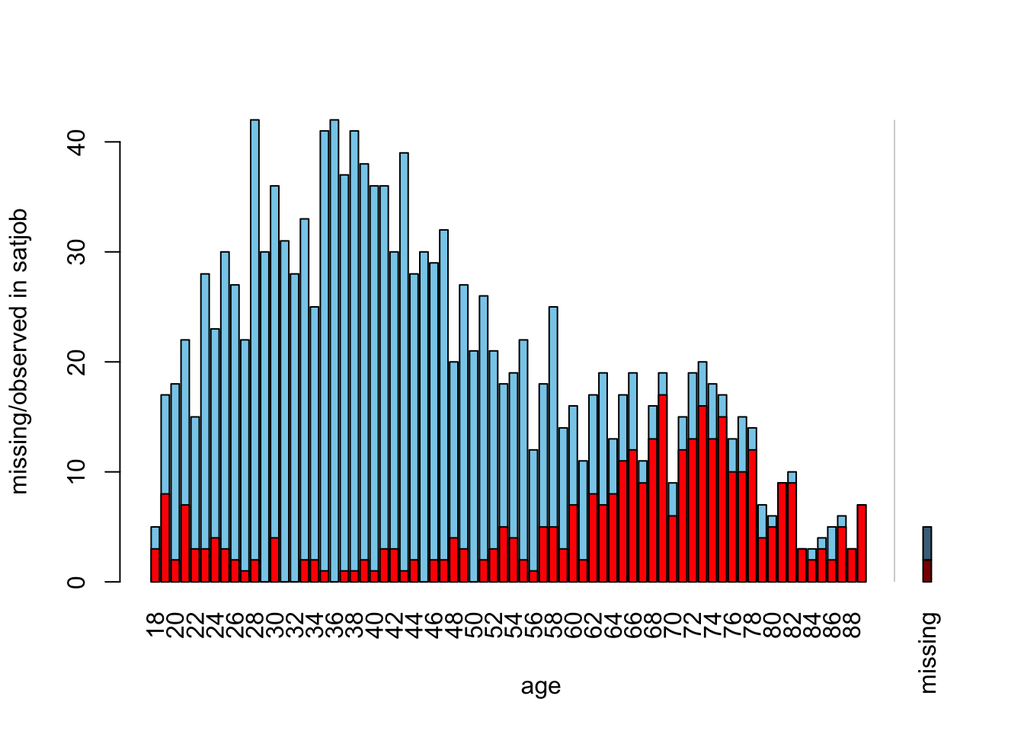

```
##
## Click in in the left margin to switch to the previous variable or in the right margin to switch to the next variable.
## To regain use of the VIM GUI and the R console, click anywhere else in the graphics window.
```

```r
histMiss(df[,c('age','satjob')])
```

### subset

Since there are a lot of missing values, Bill performed the analyses only on a subset of the variables. He used this subset function but also presented the alternatives shown further below.

###### boolean selection (logicals)

To select rows, in this example an expression is used that results in either TRUE or FALSE.

###### select

This argument here takes a character vector that specifies which columns will be included.

```r
#Before subsetting
head(df)
```

|  | id | age | sex | satjob | educ | hours | life | income |
| --- | --- | --- | --- | --- | --- | --- | --- | --- |
| 1 | 1 | 43 | Male | Not very satisfied | 11 | 35 | Routine | $35000-39999 |
| 2 | 2 | 44 | Male | Not very satisfied | 16 | 21 | Exciting | $40000-49999 |
| 3 | 3 | 43 | Female | Very satisfied | 16 | 45 | Exciting | $40000-49999 |
| 4 | 4 | 45 | Female | Not very satisfied | 15 | 20 | NA | NA |
| 5 | 5 | 78 | Female | NA | 17 | NA | Exciting | NA |
| 6 | 6 | 83 | Male | NA | 11 | NA | Routine | NA |

```r
#subsetting
df_sub <- subset(df, satjob!=FALSE & life != FALSE, select=c('id', 'sex', 'satjob', 'life'))
#after subsetting
head(df_sub)
```

|  | id | sex | satjob | life |
| --- | --- | --- | --- | --- |
| 1 | 1 | Male | Not very satisfied | Routine |
| 2 | 2 | Male | Not very satisfied | Exciting |
| 3 | 3 | Female | Very satisfied | Exciting |
| 7 | 7 | Female | Very satisfied | Routine |
| 9 | 9 | Male | Very satisfied | Exciting |
| 10 | 10 | Female | Very satisfied | Exciting |

### complete.cases & na.omit

Alternative to subset.

```r
#using complete.cases
df_sub1 <- df[complete.cases(df), c(1, 3, 4, 7)]
head(df_sub1)
```

|  | id | sex | satjob | life |
| --- | --- | --- | --- | --- |
| 1 | 1 | Male | Not very satisfied | Routine |
| 2 | 2 | Male | Not very satisfied | Exciting |
| 3 | 3 | Female | Very satisfied | Exciting |
| 7 | 7 | Female | Very satisfied | Routine |
| 9 | 9 | Male | Very satisfied | Exciting |
| 10 | 10 | Female | Very satisfied | Exciting |

```r
#using na.omit
df_sub2 <- na.omit(df[,c(1, 3, 4, 7)])
head(df_sub2)
```

|  | id | sex | satjob | life |
| --- | --- | --- | --- | --- |
| 1 | 1 | Male | Not very satisfied | Routine |
| 2 | 2 | Male | Not very satisfied | Exciting |
| 3 | 3 | Female | Very satisfied | Exciting |
| 7 | 7 | Female | Very satisfied | Routine |
| 9 | 9 | Male | Very satisfied | Exciting |
| 10 | 10 | Female | Very satisfied | Exciting |

## Fit model

### glm

This function is used to perform the logistic regression.

###### model

Specify the model with the notation like you are used to from the function `lm()`.

###### data

Specifies the dataframe where the data is stored.

###### family

Specifies the probability distribution function that is used for the generalized linear model. For logistic regression we will use the *binomial distribution*.

*Note:*  
*Bill notes that the default of the glm function is to use listwise deletion.*

```r
logmodel <- glm(satjob ~ sex + life, data=df_sub, family=binomial())
#model with interaction
logmodel2 <- glm(satjob ~ sex * life, data = df_sub, family = binomial())
```

### relevel

In this example, to directly see whether routine&exciting lifestyles differ on job satisfaction, you need to let R pick a different reference group. One way is to change the order of the levels of the factor lifestyle with the function `relevel()`:

```r
df_sub$life <- relevel(df_sub$life, ref=2)
logmodel1 <- glm(satjob ~ sex + life, data=df_sub, family=binomial())
# here you can see that the reference group is now different:
summary(logmodel)
```

```
##
## Call:
## glm(formula = satjob ~ sex + life, family = binomial(), data = df_sub)
##
## Deviance Residuals:
##     Min       1Q   Median       3Q      Max
## -2.0839  -1.0937   0.8413   0.8751   1.3047
##
## Coefficients:
##              Estimate Std. Error z value Pr(>|z|)
## (Intercept)   2.05027    0.54564   3.758 0.000172 ***
## sexFemale    -0.09433    0.15495  -0.609 0.542670
## lifeRoutine  -1.19360    0.54662  -2.184 0.028993 *
## lifeExciting -2.25033    0.54430  -4.134 3.56e-05 ***
## ---
## Signif. codes:  0 '***' 0.001 '**' 0.01 '*' 0.05 '.' 0.1 ' ' 1
##
## (Dispersion parameter for binomial family taken to be 1)
##
##     Null deviance: 1029.16  on 753  degrees of freedom
## Residual deviance:  965.96  on 750  degrees of freedom
## AIC: 973.96
##
## Number of Fisher Scoring iterations: 4
```

```r
summary(logmodel1)
```

```
##
## Call:
## glm(formula = satjob ~ sex + life, family = binomial(), data = df_sub)
##
## Deviance Residuals:
##     Min       1Q   Median       3Q      Max
## -2.0839  -1.0937   0.8413   0.8751   1.3047
##
## Coefficients:
##              Estimate Std. Error z value Pr(>|z|)
## (Intercept)   0.85667    0.14577   5.877 4.18e-09 ***
## sexFemale    -0.09433    0.15495  -0.609    0.543
## lifeDull      1.19360    0.54662   2.184    0.029 *
## lifeExciting -1.05673    0.15616  -6.767 1.32e-11 ***
## ---
## Signif. codes:  0 '***' 0.001 '**' 0.01 '*' 0.05 '.' 0.1 ' ' 1
##
## (Dispersion parameter for binomial family taken to be 1)
##
##     Null deviance: 1029.16  on 753  degrees of freedom
## Residual deviance:  965.96  on 750  degrees of freedom
## AIC: 973.96
##
## Number of Fisher Scoring iterations: 4
```

## Assumption 1: Linearity

There should be a linear relationship between any continuous variable and the logit of the outcome. This can be tested by examining the interaction between the continuous predictor and its log transformation (only for continuous predictors). Since, in this example there are no continuous variables, I simulate a continuous variable to show how this looks in R. Just check if the interaction is significant. If yes, then the assumption is violated.

*Note:*  
*The function* `rnorm()` *is covered in the introduction where we learned about simulating data.*

```r
#simulate a continuous pred
df_sub$cont_pred <- rnorm(754,10,2)
#check linearity assumption
##first create interaction term between cont_pred and its log
df_sub$cont_pred_int <- log(df_sub$cont_pred)*df_sub$cont_pred
#run the model with the interaction included. If the interaction term is significant, then the assumption of linearity is violated
logmodel3 <- glm(satjob ~ cont_pred + cont_pred_int, data = df_sub, family = binomial())
summary(logmodel3)
```

```
##
## Call:
## glm(formula = satjob ~ cont_pred + cont_pred_int, family = binomial(),
##     data = df_sub)
##
## Deviance Residuals:
##    Min      1Q  Median      3Q     Max
## -1.333  -1.302   1.037   1.054   1.120
##
## Coefficients:
##               Estimate Std. Error z value Pr(>|z|)
## (Intercept)    0.19922    2.25603   0.088    0.930
## cont_pred      0.08253    0.77013   0.107    0.915
## cont_pred_int -0.03147    0.23537  -0.134    0.894
##
## (Dispersion parameter for binomial family taken to be 1)
##
##     Null deviance: 1029.2  on 753  degrees of freedom
## Residual deviance: 1028.8  on 751  degrees of freedom
## AIC: 1034.8
##
## Number of Fisher Scoring iterations: 4
```

## Assumption 2: Independence of errors

### dwt (car)

To check for independence of errors. Values <1 or >3 indicate violation. The close to 2, the better. Just enter the model as argument as follows:

```r
library(car)
dwt(logmodel)
```

```
##  lag Autocorrelation D-W Statistic p-value
##    1     -0.01427466      2.027084   0.688
##  Alternative hypothesis: rho != 0
```

## Assumption 3: Multicolliniearity

We check multicollinearity with the variance inflation factor. For continuous predictors (which are not in this example) the GVIF can be used. For categorical predictors the $GVIF^{\frac{1}{2*Df}}$ should be used. Values above 10 indicate a problem.

### vif (car)

Only argument needed is the model.

```r
vif(logmodel)
```

```
##          GVIF Df GVIF^(1/(2*Df))
## sex  1.003113  1        1.001555
## life 1.003113  2        1.000777
```

## Outliers & Influential cases

Bill presents 3 steps to check for outliers and influential cases as well as some diagnostic plots:

1. Examine standardized residuals (to identify outliers)
- 5% of cases should have residuals > 2
- 1% should have residuals > 2.5
- None should be >3
- It is not a general rule but Bill considers residuals with an absolute value >3 as outliers

### rstandard

To obtain the standardized residuals. The only argument needed is the general linear model (here the logistic regression model). Below I also use the functions `sum()`, `mean()` and `abs()`. I assumed that these are self explanatory because we all used them very often already.

```r
#store sresids in dataframe
df_sub$sresiduals <- rstandard(logmodel)
#check the criteria mentioned above
mean(abs(df_sub$sresiduals)>2)
```

```
## [1] 0.00530504
```

```r
mean(abs(df_sub$sresiduals)>2.5)
```

```
## [1] 0
```

```r
sum(abs(df_sub$sresiduals)>3)
```

```
## [1] 0
```

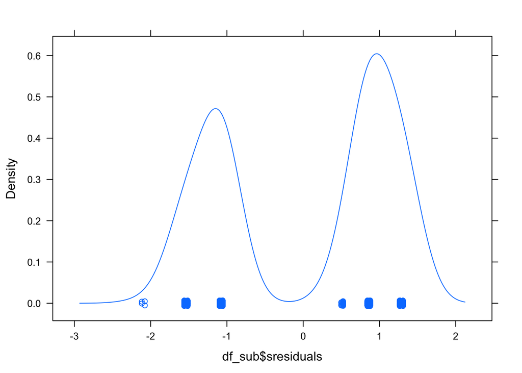

```r
#plot (see below for function explanation)
library(lattice)
densityplot(df_sub$sresiduals)
```

### densityplot (lattice)

As the functionname implies, it creates a densityplot of the values that are passed in as an argument. There are several options available but these have not been presented in the material of logistic regression but should be covered in the graphics section or the introduction section.

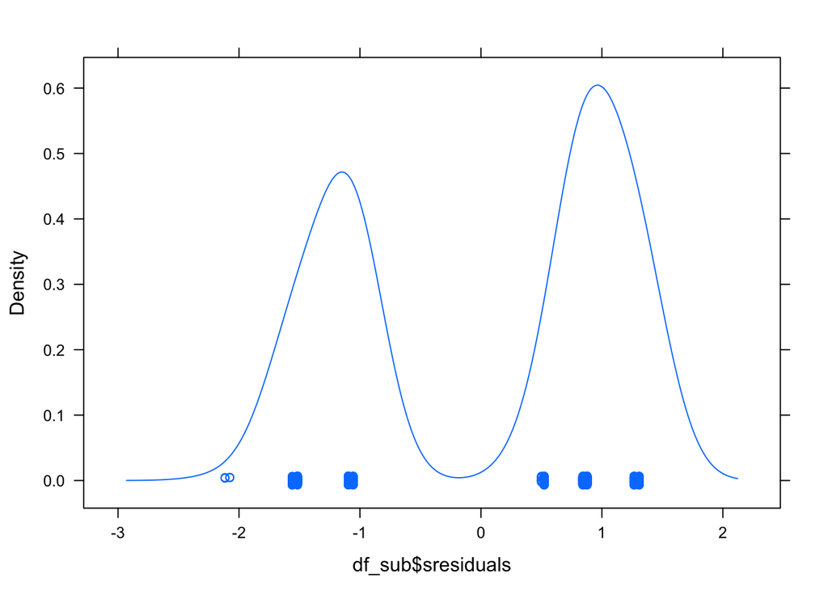

```r
library(lattice)
densityplot(df_sub$sresiduals)
```

2. Examine DFBetas (to identify influential cases)
- no value should be above 1

### dfbeta

Again, use the model as argument and it will return the dfbeta values:

```r
dfbeta_val <- dfbeta(logmodel)
sum(abs(dfbeta_val>1))
```

```
## [1] 0
```

```r
max(dfbeta_val)
```

```
## [1] 0.1969719
```

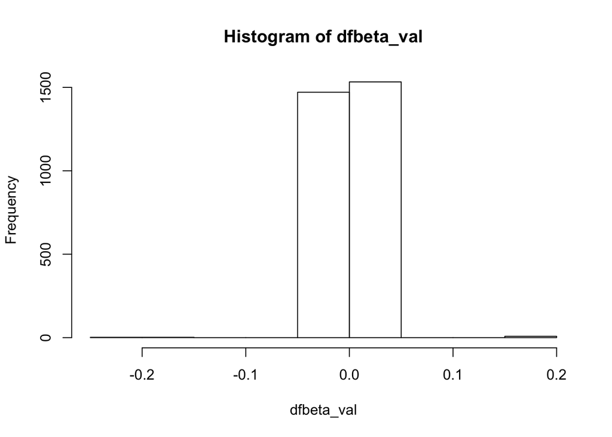

```r
hist(dfbeta_val)
```

3. Calculate leverage (to identify influential cases)
- Calculate: $\frac{k+1}{n}$, where k is the number of predictors
- Values larger than 2x or 3x the resulting value can be considered influential cases

### hatvalues

With this function we can easily get the hatvalues (leverage of values). Again, the only argument needed is the model. I apply the rules mentioned above as well:

```r
df_sub$leverage <- hatvalues(logmodel)
cutoff <- 3*(2+1)/(754)
sum(df_sub$leverage>cutoff)
```

```
## [1] 33
```

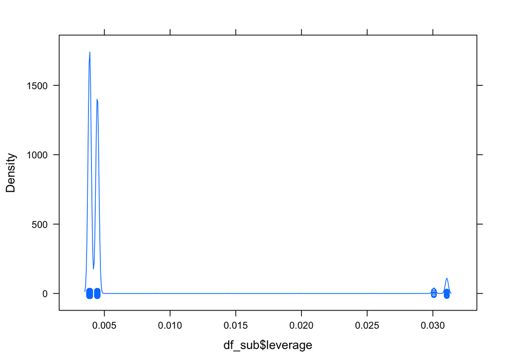

```r
densityplot(df_sub$leverage)
```

## Model evaluation and interpretation

```r
summary(logmodel)
```

```
##
## Call:
## glm(formula = satjob ~ sex + life, family = binomial(), data = df_sub)
##
## Deviance Residuals:
##     Min       1Q   Median       3Q      Max
## -2.0839  -1.0937   0.8413   0.8751   1.3047
##
## Coefficients:
##              Estimate Std. Error z value Pr(>|z|)
## (Intercept)   2.05027    0.54564   3.758 0.000172 ***
## sexFemale    -0.09433    0.15495  -0.609 0.542670
## lifeRoutine  -1.19360    0.54662  -2.184 0.028993 *
## lifeExciting -2.25033    0.54430  -4.134 3.56e-05 ***
## ---
## Signif. codes:  0 '***' 0.001 '**' 0.01 '*' 0.05 '.' 0.1 ' ' 1
##
## (Dispersion parameter for binomial family taken to be 1)
##
##     Null deviance: 1029.16  on 753  degrees of freedom
## Residual deviance:  965.96  on 750  degrees of freedom
## AIC: 973.96
##
## Number of Fisher Scoring iterations: 4
```

To evaluate whether a single predictor is significant, you could look at the **z-statistic (or Wald statistic)**. Above, the coefficients of lifeRoutine and lifeExciting are significant according to this statistic. However, several authors depreciate the use of this statistic for different reasons. Field (2012) mentions that large coefficients could make the SE inflate, leading to underestimation of the z-statistic.

$\chi^2 = -2*LL_{baseline}-(-2*LL_{new})$, with $df = k_{new} -k_{baseline}$

I show below how to obtain the deviance of a model. Note that if you test a model against the model with only the intercept, you use the null-deviance. But if you compare models that have predictors you need to obtain the deviance of both models. Once you have the deviance statistics, you also obtain the degrees of freedom of and use the function `pchisq()` to calculate the likelihood ratio with the above formula and check the p-value of the likelihood ratio.

### pchisq

This function returns the p-value for a certain $\chi^2$ statistic. You need to pass in the following two arguments as shown in the example below.

###### $\chi^2$ statistic

###### degrees of freedom

```r
baseline_deviance <- logmodel$null.deviance
new_deviance <- logmodel$deviance
modelChi <- baseline_deviance - new_deviance
chi_df <- logmodel$df.null - logmodel$df.residual
chisq.prob <- 1 - pchisq(modelChi, chi_df)
modelChi; chi_df; chisq.prob
```

```
## [1] 63.20087
```

```
## [1] 3
```

```
## [1] 1.216804e-13
```

Thus, in this case the new model predicts the outcome significantly better than the baseline model.

### anova

As an alternative, we can use the function ‘anova()’ to let it check the difference between two models. Here I compare logmodel2 with logmodel1 instead of logmodel1 against the nullmodel. It shows the likelihood-ratio (under deviance) but it does not calculate the significance.

```r
anv_object <- anova(logmodel, logmodel2)
anv_object
```

|  | Resid. Df | Resid. Dev | Df | Deviance |
| --- | --- | --- | --- | --- |
| 1 | 750 | 965.9599 | NA | NA |
| 2 | 748 | 964.5507 | 2 | 1.409211 |

```r
anv_object$Deviance[2]
```

```
## [1] 1.409211
```

We can also obtain different *pseudo R-squares* and use them as an effect size of our model. Bill does not explain much about them. I think it is sufficient if we know that there exist these analogues to $R^2$ (in linear regression) and that you can interpret them more or less in a similar way. Maybe also remember their names. I don’t think that we need to remember the formula’s to calculate them. Here is how you can calculate them in R:

```r
#Hosmer & Lemeshow's
R2.hl<-modelChi/logmodel$null.deviance
#Cox & Snell's
R.cs <- 1 - exp ((logmodel$deviance - logmodel$null.deviance)/754)
#Nagelkerke's
R.n <- R.cs /( 1- ( exp (-(logmodel$null.deviance/ 754))))
R2.hl; R.cs; R.n
```

```
## [1] 0.0614101
```

```
## [1] 0.08040395
```

```
## [1] 0.1079824
```

## oddsratios

The oddsratio for predictor $X_1$ are $e^{b_1}$ and can be interpreted as a factor by which the odds of the outcome happening change for a one unit increase in $X_1$. If the oddsratio is 1, then the odds of the outcome remain unchanged. Bill mentions in his presentation that he wants us to take the inverse but he gets confused himself and makes mistakes at this point. I don’t know why he has a problem just reporting the oddsratio but I know that he cut off points in the last exam so if someone does know and is able to explain what he wants instead, maybe send me a message and I will add the explanation here. Remember that the exponentiated confidence intervals for oddsratios should not include 1 for the coefficient to be a significant predictor as opposed to 0 for coefficients in e.g. linear regression.

### exp

This is the math function that represents $e^(x)$. We can use it to interpret the coefficients as odds ratio.

```r
exp(logmodel$coefficients)
```

```
##  (Intercept)    sexFemale  lifeRoutine lifeExciting
##    7.7700061    0.9099800    0.3031289    0.1053647
```

```r
#the confint function is self-explanatory...
exp(confint(logmodel))
```

```
##                   2.5 %     97.5 %
## (Intercept)  2.97096398 26.6791248
## sexFemale    0.67117679  1.2325086
## lifeRoutine  0.08818527  0.7952406
## lifeExciting 0.03075298  0.2747995
```

# Multinomial logistic regression

Since we have more than 2 categories in the outcome variable, we need to choose a reference group. The other two categories are then compared to this reference group. If you would want to change the reference group, you can use the function `relevel()` or you simply specify it with the argument ‘reflevel’ in the function `mlogit`. There is also an additional assumption. Finally, instead of the function `glm()`, you have to use the `mlogit()` function (this function is somewhat different to what we know from lm what about the model specification). But for the rest everything is the same. So, if you understand the concepts of binary LR, then you can apply them here. The model diagnostics is exactly the same. But you should know that Andy Field does not show how to obtain hatvalues and dfbeta and Bill did write in his script that he was unable to do that. You can do this by hand in R but I am sure they do not expect this from us. Once you have these values, the interpretation would be the same.

**Additional Assumption: Independence of Irrelevant Alternatives (IIA)**:  
The odds of choosing A over B should not depend on whether some other alternative C is present or absent. There are the *Hausman-McFadden test* and the *Small-Hsiao test*.

### mlogit.data (mlogit)

The function mlogit requires the date to be in a specific format. The function `mlogit.data()` can be used to achieve this. Bill used the following function arguments:

###### choice

```r
library(mlogit)
mlog1 <-mlogit.data(df_sub, choice ="life", shape ="wide")
head(mlog1)
```

|  | id | sex | satjob | life | cont_pred | cont_pred_int | sresiduals | leverage | chid | alt |
| --- | --- | --- | --- | --- | --- | --- | --- | --- | --- | --- |
| 1.Dull | 1 | Male | Not very satisfied | FALSE | 10.24963 | 23.85337 | 0.8431506 | 0.004445223 | 1 | Dull |
| 1.Exciting | 1 | Male | Not very satisfied | FALSE | 10.24963 | 23.85337 | 0.8431506 | 0.004445223 | 1 | Exciting |
| 1.Routine | 1 | Male | Not very satisfied | TRUE | 10.24963 | 23.85337 | 0.8431506 | 0.004445223 | 1 | Routine |
| 2.Dull | 2 | Male | Not very satisfied | FALSE | 9.26669 | 20.63160 | 1.2663004 | 0.004475816 | 2 | Dull |
| 2.Exciting | 2 | Male | Not very satisfied | TRUE | 9.26669 | 20.63160 | 1.2663004 | 0.004475816 | 2 | Exciting |
| 2.Routine | 2 | Male | Not very satisfied | FALSE | 9.26669 | 20.63160 | 1.2663004 | 0.004475816 | 2 | Routine |

### mlogit (mlogit)

This is the function we use to fit the multinomial logistic regression model. The specification of the model is different compared to what we are used to. The difference is mentioned under the *model* argument.

###### model

The specification of the model is different than we are used to because we include a ‘1’ followed by ‘|’ to specify the intercept.

###### data

Dataframe as we are used to.

###### reflevel

Reference group.

```r
mlogmodel1<-mlogit(life ~ 1|sex * satjob, data = mlog1, reflevel = 1)
mlogmodel2<-mlogit(life ~ 1|sex * satjob, data = mlog1, reflevel = 2)

#residuals and fitted values can be obtained from the model
df_diag <- c(mlogmodel1$residuals, mlogmodel1$fitted.values)

#check out the model
summary(mlogmodel1)
```

```
##
## Call:
## mlogit(formula = life ~ 1 | sex * satjob, data = mlog1, reflevel = 1,
##     method = "nr", print.level = 0)
##
## Frequencies of alternatives:
##     Dull Exciting  Routine
## 0.043767 0.497347 0.458886
##
## nr method
## 7 iterations, 0h:0m:0s
## g'(-H)^-1g = 8.43E-05
## successive function values within tolerance limits
##
## Coefficients :
##                                             Estimate Std. Error t-value
## Exciting:(intercept)                         3.83945    0.71467  5.3723
## Routine:(intercept)                          3.09104    0.72300  4.2753
## Exciting:sexFemale                           0.23807    1.00957  0.2358
## Routine:sexFemale                            0.35893    1.01912  0.3522
## Exciting:satjobNot very satisfied           -1.46787    0.81667 -1.7974
## Routine:satjobNot very satisfied            -0.34560    0.82144 -0.4207
## Exciting:sexFemale:satjobNot very satisfied -1.21205    1.11000 -1.0919
## Routine:sexFemale:satjobNot very satisfied  -1.32787    1.11525 -1.1907
##                                              Pr(>|t|)
## Exciting:(intercept)                        7.772e-08 ***
## Routine:(intercept)                         1.909e-05 ***
## Exciting:sexFemale                            0.81358
## Routine:sexFemale                             0.72469
## Exciting:satjobNot very satisfied             0.07227 .
## Routine:satjobNot very satisfied              0.67395
## Exciting:sexFemale:satjobNot very satisfied   0.27486
## Routine:sexFemale:satjobNot very satisfied    0.23379
## ---
## Signif. codes:  0 '***' 0.001 '**' 0.01 '*' 0.05 '.' 0.1 ' ' 1
##
## Log-Likelihood: -600.42
## McFadden R^2:  0.054003
## Likelihood ratio test : chisq = 68.552 (p.value = 8.0999e-13)
```

```r
summary(mlogmodel2)
```

```
##
## Call:
## mlogit(formula = life ~ 1 | sex * satjob, data = mlog1, reflevel = 2,
##     method = "nr", print.level = 0)
##
## Frequencies of alternatives:
## Exciting     Dull  Routine
## 0.497347 0.043767 0.458886
##
## nr method
## 7 iterations, 0h:0m:0s
## g'(-H)^-1g = 8.43E-05
## successive function values within tolerance limits
##
## Coefficients :
##                                            Estimate Std. Error t-value
## Dull:(intercept)                           -3.83945    0.71467 -5.3723
## Routine:(intercept)                        -0.74841    0.18298 -4.0902
## Dull:sexFemale                             -0.23807    1.00957 -0.2358
## Routine:sexFemale                           0.12086    0.24047  0.5026
## Dull:satjobNot very satisfied               1.46787    0.81667  1.7974
## Routine:satjobNot very satisfied            1.12227    0.23662  4.7430
## Dull:sexFemale:satjobNot very satisfied     1.21205    1.11000  1.0919
## Routine:sexFemale:satjobNot very satisfied -0.11582    0.31506 -0.3676
##                                             Pr(>|t|)
## Dull:(intercept)                           7.772e-08 ***
## Routine:(intercept)                        4.310e-05 ***
## Dull:sexFemale                               0.81358
## Routine:sexFemale                            0.61525
## Dull:satjobNot very satisfied                0.07227 .
## Routine:satjobNot very satisfied           2.106e-06 ***
## Dull:sexFemale:satjobNot very satisfied      0.27486
## Routine:sexFemale:satjobNot very satisfied   0.71316
## ---
## Signif. codes:  0 '***' 0.001 '**' 0.01 '*' 0.05 '.' 0.1 ' ' 1
##
## Log-Likelihood: -600.42
## McFadden R^2:  0.054003
## Likelihood ratio test : chisq = 68.552 (p.value = 8.0999e-13)
```

This model output already shows the likelihood ratio test. This test here compares the model with predictors against the baseline model. If significant, it means that the model explains more variance than the baseline model. Instead of the deviance it also puts out the log-likelihood. So beware that if you want to calculate the likelihood ratio between two models that you need to multiply this by -2 to get deviance.

```r
#oddsratios with CIs
data.frame(exp(mlogmodel2$coefficients))
```

|  | exp.mlogmodel2.coefficients. |
| --- | --- |
| Dull:(intercept) | 0.0215054 |
| Routine:(intercept) | 0.4731183 |
| Dull:sexFemale | 0.7881502 |
| Routine:sexFemale | 1.1284669 |
| Dull:satjobNot very satisfied | 4.3399952 |
| Routine:satjobNot very satisfied | 3.0718182 |
| Dull:sexFemale:satjobNot very satisfied | 3.3603684 |
| Routine:sexFemale:satjobNot very satisfied | 0.8906341 |

```r
exp(confint(mlogmodel2))
```

```
##                                                  2.5 %     97.5 %
## Dull:(intercept)                           0.005299314  0.0872721
## Routine:(intercept)                        0.330537600  0.6772026
## Dull:sexFemale                             0.108959046  5.7010485
## Routine:sexFemale                          0.704364263  1.8079246
## Dull:satjobNot very satisfied              0.875673065 21.5098069
## Routine:satjobNot very satisfied           1.931909368  4.8843217
## Dull:sexFemale:satjobNot very satisfied    0.381548731 29.5953690
## Routine:sexFemale:satjobNot very satisfied 0.480306928  1.6515044
```

The interpretation is exactly the same as with binary logistic regression. Remember that we specified a reference category above. In the model printed below the reference group is *exciting*. There is one significant predictor in the model below: Being not satisfied increases the odds of having a routine lifestyle by 3.07 (the odds of having routine life style versus exciting lifestyle). Remember that Bill wants us to report the odds ratio in a different way.

```r
summary(mlogmodel2)
```

```
##
## Call:
## mlogit(formula = life ~ 1 | sex * satjob, data = mlog1, reflevel = 2,
##     method = "nr", print.level = 0)
##
## Frequencies of alternatives:
## Exciting     Dull  Routine
## 0.497347 0.043767 0.458886
##
## nr method
## 7 iterations, 0h:0m:0s
## g'(-H)^-1g = 8.43E-05
## successive function values within tolerance limits
##
## Coefficients :
##                                            Estimate Std. Error t-value
## Dull:(intercept)                           -3.83945    0.71467 -5.3723
## Routine:(intercept)                        -0.74841    0.18298 -4.0902
## Dull:sexFemale                             -0.23807    1.00957 -0.2358
## Routine:sexFemale                           0.12086    0.24047  0.5026
## Dull:satjobNot very satisfied               1.46787    0.81667  1.7974
## Routine:satjobNot very satisfied            1.12227    0.23662  4.7430
## Dull:sexFemale:satjobNot very satisfied     1.21205    1.11000  1.0919
## Routine:sexFemale:satjobNot very satisfied -0.11582    0.31506 -0.3676
##                                             Pr(>|t|)
## Dull:(intercept)                           7.772e-08 ***
## Routine:(intercept)                        4.310e-05 ***
## Dull:sexFemale                               0.81358
## Routine:sexFemale                            0.61525
## Dull:satjobNot very satisfied                0.07227 .
## Routine:satjobNot very satisfied           2.106e-06 ***
## Dull:sexFemale:satjobNot very satisfied      0.27486
## Routine:sexFemale:satjobNot very satisfied   0.71316
## ---
## Signif. codes:  0 '***' 0.001 '**' 0.01 '*' 0.05 '.' 0.1 ' ' 1
##
## Log-Likelihood: -600.42
## McFadden R^2:  0.054003
## Likelihood ratio test : chisq = 68.552 (p.value = 8.0999e-13)
```

Field, A. (2012). *Discovering Statistics Using R*. SAGE Publications Ltd.